# A governança oceânica integrada é necessária no Oceano Atlântico Sudoeste para promover a pesca, a conservação e a resiliência às mudanças climáticas

Juliano Palacios-Abrantes, Facundo Llompart, Luís Gustavo Cardoso, Omar Defeo, Ignacio Gianelli, Andrés J. Jaureguizar, Priscila F. M. Lopes, José Angel A. Perez, Natali I. P. Piccolo, Alberto R. Piola, Andrei Polejack, Luciana F. Prado, Martin Saraceno

Março, 2026

[figure not shown]

- **NOTA: Esta é uma tradução ao português do artigo:** *Integrated ocean governance is needed in the Southwest Atlantic Ocean to foster fisheries, conservation and resilience to climate change*, escrito por Palacios-Abrantes J. e colaboradores. Disponível [online](https://doi.org/10.1007/s44289-026-00134-4).
  - Traduzido por Juliano Palacios. Revisão técnica de Luis Gustavo Cardoso, Luciana Prado e Priscila Lopes.
- **Referência**: Palacios-Abrantes, J., Llompart, F., Cardoso, L. G., Defeo, O., Gianelli, I., Jaureguizar, A. J., Lopes, P. F. M., Perez, J. A. A., Piccolo, N. I. P., Piola, A. R., Polejack, A., Prado, L. F. and Saraceno, M., 2026. Integrated ocean governance is needed in the Southwest Atlantic Ocean to foster fisheries, conservation and resilience to climate change. Discover Oceans, 3 (1), 19.

Descargar Artigo em Português

# Resumen

O Oceano Atlântico Sudoeste (OAS) é uma região de importância global, onde diversas massas de água convergem e se misturam, regulando o clima da Terra ao mesmo tempo em que promovem pescarias produtivas e alta biodiversidade marinha. A conectividade ecológica também é substancial, com múltiplas espécies e ecossistemas compartilhados entre várias jurisdições e fronteiras internacionais. No entanto, apesar de esforços históricos e de chamados mais recentes por uma gestão regional, o OAS é uma das poucas grandes regiões oceânicas sem um órgão dedicado de governança oceânica que englobe todos os recursos compartilhados. Essa desconexão é particularmente alarmante diante das mudanças climáticas, que estão alterando a distribuição e a abundância dos estoques pesqueiros, deslocando a distribuição das espécies em direção aos polos e intensificando a incerteza na gestão dos recursos marinhos. Um arcabouço regional colaborativo, baseado na gestão ecossistêmica, é urgentemente necessário para promover a gestão sustentável e reforçar a resiliência aos impactos das mudanças climáticas. À medida que o Brasil sedia uma série de reuniões das Nações Unidas sobre temas ambientais, a região enfrenta um momento decisivo: permanecer reativa a estruturas externas de governança ou desenhar proativamente marcos que reflitam prioridades regionais, equilibrem preocupações com soberania e integrem as evidências científicas à tomada de decisão de uma forma mais eficaz. Assim, convidamos formuladores de políticas, gestores e cientistas a aproveitar o momento político na América Latina para avançar uma governança oceânica integrada e multiescalar, ao mesmo tempo em que fortalecem a diplomacia científica oceânica no OAS. Este é um chamado para ajudar a navegar um futuro incerto, enfrentando desafios compartilhados e priorizando a sustentabilidade oceânica no OAS.

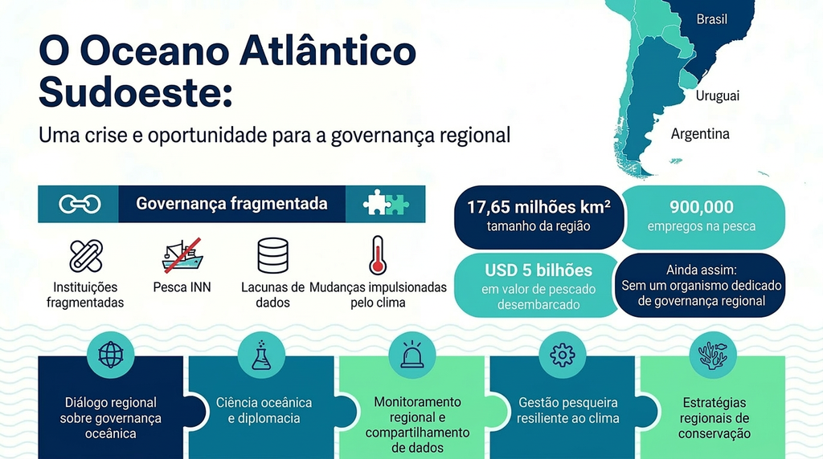

**Infográfico apresentando um resumo da pesquisa. Elaborado com ajuda de *Perpexity***

# O Oceano Atlântico Sudoeste: uma região de importância ecológica e socioeconômica

Com extensão de 17,65 milhões de km² entre 5°N e 60°S, o Oceano Atlântico Sudoeste (OAS) abrange características oceânicas, biogeográficas e ecológicas diversas, que sustentam biodiversidade excepcional e pescarias de alto valor socioeconômico [Fig. 1](https://link.springer.com/article/10.1007/s44289-026-00134-4/figures/1). Distribuída dentro e além das jurisdições nacionais, a região abriga hotspots de biodiversidade, corredores migratórios e habitats críticos que sustentam comportamentos de desova, acasalamento, berçário e alimentação para múltiplas espécies importantes e vulneráveis, incluindo peixes, tubarões, cefalópodes e mamíferos marinhos, como baleias-francas-austrais, jubartes e orcas [1-3]. Essas características resultam de feições geomorfológicas, hidrográficas e biogeoquímicas que delimitam províncias biogeográficas e ecorregiões distintas, sustentando altos níveis de endemismo e coesão ecológica [4,5].

A importância ecológica do OAS também se estende às pescarias [Fig. 2](https://link.springer.com/article/10.1007/s44289-026-00134-4/figures/2). Designado pela Organização das Nações Unidas para a Alimentação e a Agricultura (FAO) como Área Principal de Pesca 41 [Fig. 1](https://link.springer.com/article/10.1007/s44289-026-00134-4/figures/1), o OAS possui mais de 32.000 embarcações artesanais e industriais, empregando 896.000 pessoas. Em 2021, as capturas nessas pescarias multiespecíficas foram estimadas em 2 milhões de toneladas, e avaliadas em 5 bilhões de dólares [6]. Especificamente no norte do Brasil (ao norte de 20°S), a plataforma continental sustenta pescarias multiespecíficas de pequena escala, embora frequentemente com cobertura estatística limitada. Mais ao sul, pescarias industriais se desenvolveram ao longo das plataformas brasileira, uruguaia e argentina, direcionadas a estoques compartilhados de alto valor comercial [7–9]. Além disso, no OAS, há uma alta conectividade entre regiões. Por exemplo, no inverno, estoques de peixes, camarões e lulas se deslocam para o norte, das plataformas do norte da Patagônia e do Uruguai para a plataforma sul do Brasil, onde representam um componente substancial da indústria pesqueira nessa região produtiva e economicamente importante do Brasil [10,11]. Essa conectividade resulta em grande número de estoques compartilhados (transfronteiriços, transzonais e transzonais altamente migratórios; Quadro 1) na composição da captura desses países [Fig. 2b](https://link.springer.com/article/10.1007/s44289-026-00134-4/figures/2). [12–14].

Quadro 1. Glossário de termos incluídos neste artigo

[output not shown]

A importância ecológica e a elevada produtividade pesqueira do OAS são sustentadas por condições oceanográficas únicas e complexas [Fig. 1](https://link.springer.com/article/10.1007/s44289-026-00134-4/figures/1). Sob a influência de correntes de contorno oeste relativamente intensas, nomeadamente a Corrente Norte do Brasil (NBC), a Corrente do Brasil (BC) e a Corrente das Malvinas (MC) [Fig. 1](https://link.springer.com/article/10.1007/s44289-026-00134-4/figures/1), a região é caracterizada por intensa mistura entre águas subtropicais e subantárticas [15,16]. Em combinação com zonas frontais, redemoinhos, ressurgência e descargas de grandes bacias hidrográficas, esses processos são responsáveis por ecossistemas altamente produtivos [17–20]. A forte variabilidade espacial e temporal da região molda a distribuição e a abundância das comunidades marinhas, posicionando o OAS entre as regiões marinhas mais produtivas do mundo [6,8,21,22].

## Governança oceânica no OAS

Brasil, Uruguai e Argentina são signatários de várias convenções e tratados das Nações Unidas relacionados à governança oceânica e têm colaborado extensivamente na implementação regional desses acordos. Por exemplo, todos são signatários da Convenção das Nações Unidas sobre o Direito do Mar (UNCLOS), da Convenção sobre Diversidade Biológica (CBD) e do Acordo para a Conservação e o Uso Sustentável da Diversidade Biológica Marinha de Áreas Além da Jurisdição Nacional (Acordo BBNJ), o qual foi ratificado por Brasil e Uruguai. Regionalmente, Brasil e Uruguai mantêm um forte histórico de cooperação no âmbito da Comissão Internacional para a Conservação dos Atuns do Atlântico (ICCAT), particularmente por meio de análises conjuntas e contribuições coordenadas para avaliações de estoques (por exemplo, [26,27]). Além disso, todos são signatários da Zona de Paz e Cooperação do Atlântico Sul ([ZOPACAS](https://www.abc.gov.br/zopacas/default_en.aspx)), um alinhamento político voltado à promoção da paz, da segurança e da solidariedade regional entre nações costeiras do Atlântico Sul na África e na América do Sul.

No entanto, os esforços integrados em conservação e governança pesqueira permanecem limitados, como exemplificado pelo Acordo sobre Medidas do Estado do Porto (PSMA). O PSMA é um acordo vinculante e instrumento-chave no âmbito do Código de Conduta para a Pesca Responsável. Ele exige que as Partes reforcem a supervisão de embarcações pesqueiras estrangeiras para combater a pesca ilegal, não declarada e não regulamentada (INN) por frotas de águas distantes. Seu objetivo é reduzir o incentivo para que embarcações envolvidas em INN continuem operando, impedindo-as de desembarcar suas capturas em portos de Partes do PSMA, ao mesmo tempo em que protege mercados nacionais e internacionais [28]. No entanto, até o momento, o Uruguai é a única Parte no OAS que ratificou o PSMA. Talvez o melhor exemplo de cooperação trilateral tenha sido a Comisión Asesora Regional de Pesca para el Atlántico Sudoccidental (CARPAS), estabelecida pela FAO em 1962 [8]. A CARPAS teve papel importante como Comissão Consultiva Regional de Pesca para o Atlântico Sudoeste, coordenando estatísticas pesqueiras, promovendo pesquisas biológicas e realizando avaliações de estoques. Contudo, a CARPAS foi oficialmente extinta pela Resolução 13/97 da Conferência da FAO, em 1997, após a criação das ZEEs e o estabelecimento, em 1976, da Comisión Técnica Mixta del Frente Marítimo (CTMFM). A CTMFM avalia o estado dos recursos pesqueiros e propõe medidas de manejo dentro da Zona Común de Pesca Argentino-Uruguaya (ZCPAU). Hoje, a ZCPAU opera como uma área de soberania compartilhada para recursos pesqueiros transfronteiriços da Argentina e do Uruguai. A CTMFM é reconhecida pela FAO como o único organismo pesqueiro regional no Atlântico Sudoeste. Embora existam arranjos bilaterais sólidos entre Argentina e Uruguai, o engajamento do Brasil permaneceu comparativamente incipiente desde o fim da CARPAS, com a maior parte dos esforços sendo impulsionada por cooperação científica clássica em diversos temas de pesquisa marinha [2,7,8].

## Os desafios no OAS

Tensões geopolíticas bem documentadas no OAS continuam moldando as abordagens regionais de governança oceânica e gestão sustentável de recursos marinhos, sendo essas dinâmicas cada vez mais agravadas pela dupla pressão da pesca INN e das mudanças climáticas. As iniciativas de conservação também permanecem limitadas, fragmentadas e frequentemente desconectadas da gestão pesqueira, minando a capacidade de salvaguardar serviços ecossistêmicos e de responder de forma efetiva a pressões cumulativas, incluindo sobrepesca, degradação de habitats e variabilidade impulsionada pelo clima.

### Desafios de governança

As pescarias no OAS ilustram as tensões entre governança, competição econômica e sustentabilidade. A presença crescente de frotas estrangeiras com tecnologias de exploração de ponta, particularmente da Ásia e da Europa, direcionadas a recursos altamente valiosos como lula e atuns, promove competição desigual tanto com frotas domésticas industriais quanto com frotas de pequena escala [29,30]. Esse desequilíbrio é ainda intensificado por subsídios externos e pelo uso de bandeiras de conveniência, criando assimetrias de mercado e pressões sobre a segurança alimentar de comunidades locais [31]. Paralelamente, essas dinâmicas refletem a expansão de pescarias não regulamentadas, como as de lula, que exploram lacunas institucionais em áreas de alto-mar e nas margens das jurisdições nacionais [32]. Esse desafio é agravado pela ausência do Brasil e da Argentina no PSMA. A proximidade geográfica entre Uruguai, Brasil e Argentina reduz a efetividade desse acordo, que depende em parte da dificuldade de alcançar portos fora do marco do PSMA. Quando membros do PSMA fazem fronteira com Estados não membros, embarcações estrangeiras podem desviar para portos fora do PSMA ou oportunisticamente re-hastear bandeiras domésticas, prática conhecida como “domesticação de bandeira” [31]. Entre 2016 e 2021, o número de visitas portuárias por embarcações que re-hastearam bandeira doméstica no Brasil e no Uruguai aumentou cerca de 27% e 57%, respectivamente [31]. Embora a ratificação do PSMA represente um passo importante para enfrentar a pesca INN na região, sua efetividade depende, em última instância, de implementação, coordenação e medidas nacionais complementares. Nesse contexto, o papel do Brasil como signatário (mas não Parte ratificante) e a situação da Argentina, com controles portuários existentes e status de não signatária, evidenciam tanto as oportunidades quanto as limitações de depender apenas do PSMA.

A disputa de soberania entre Argentina e Reino Unido sobre as Ilhas Malvinas/Falkland, Geórgia do Sul, Ilhas Sandwich do Sul e áreas marítimas circundantes, intensificada pelo potencial de exploração de recursos marinhos compartilhados, continua sendo um desafio geopolítico central. Nessa área, mais de 42 pescarias costeiras de pequena escala estão distribuídas ao longo da costa patagônica da Argentina [33], com a maior parte sendo gerida de forma independente e com pouco avanço em direção a pesquisas conjuntas ou acordos coordenados e inclusivos de manejo [34]. Nesse cenário, as diplomacias do Brasil, do Uruguai e da Argentina têm resistido ao estabelecimento de uma Organização Regional de Ordenamento Pesqueiro (RFMO) para o OAS. Tal resistência decorre não apenas de disputas históricas de longa data, mas também de preocupações de que a regulação multilateral possa fornecer uma base legal para atores extra-regionais, diluindo a soberania nacional e enfraquecendo a autonomia regional sobre estoques pesqueiros estratégicos [8]. Lições para a região podem ser extraídas de outros contextos, como o dos Estados insulares do Pacífico, que temiam que o estabelecimento da Western and Central Pacific Fisheries Commission (WCPFC) pudesse servir de base legal para atores extra-regionais diluírem a soberania dos Estados insulares. Essas preocupações levaram ao desenvolvimento de estratégias para resistir à inclusão de nações pesqueiras de águas distantes na gestão pesqueira, uma vez que o Acordo das Nações Unidas sobre Estoques Pesqueiros (UNFSA) foi estabelecido, fornecendo legitimidade jurídica internacional à sua posição [35]. Além disso, ao sul de 45°S, valiosos estoques transfronteiriços são explorados por frotas de múltiplas nacionalidades. Por exemplo, a pescaria de caranguejos no Canal de Beagle, com captura conjunta da centolla-do-sul *Lithodes santolla* e do caranguejo-pedra *Paralomis granulosa*, é compartilhada entre Argentina e Chile, mas gerida de forma independente [34]. A governança nessa região é fragmentada e frequentemente unilateral, com a falta de integração de evidências científicas à tomada de decisão. A colaboração passada por meio da South Atlantic Fisheries Commission produziu algumas medidas conjuntas, mas está suspensa desde 2020. Mais recentemente, iniciativas bilaterais de pesquisa, como aquelas entre Argentina e Chile sobre a merluza-negra, mostram potencial para melhor cooperação [36]. Sob uma perspectiva puramente ecológica, uma estratégia colaborativa de manejo parece promissora. No entanto, as disputas de soberania em torno das Ilhas Malvinas/Falkland tornam a área uma das zonas pesqueiras mais desafiadoras do mundo em termos geopolíticos e ambientais.

### Lacunas de dados limitam a conservação e o manejo pesqueiro efetivos

A conservação e o manejo efetivos das pescarias no OAS são restringidos por deficiências persistentes de dados. Por exemplo, espécies de preocupação para conservação na região, como tubarões, possuem dados observacionais limitados [3], o entendimento da estrutura de assembleias de peixes recifais é restrito a sub-regiões específicas [37], ecossistemas de mar profundo são virtualmente inexplorados por cobertura visual [38], e os dados pesqueiros são frequentemente incompletos [39]. Todas essas limitações têm implicações para os esforços regionais de proteção da biodiversidade marinha e de manejo sustentável das pescarias.

Um obstáculo crítico para viabilizar o manejo, inclusive o manejo cooperativo, é a falta generalizada de dados confiáveis e consistentes sobre pescarias em toda a região, especialmente para pescarias de pequena escala, que são cronicamente subnotificadas na América Latina e no Caribe [39]. Embora não seja exclusiva, essa deficiência geral de dados pode ser exemplificada no OAS pelas pescarias de pequena escala do norte do Brasil [40]. A coleta sistemática de dados no Brasil tem sido inconsistente desde o início da década de 2010, em grande parte devido à instabilidade institucional [40]. De 1990 a 2007, o Instituto Brasileiro do Meio Ambiente (IBAMA) coordenou estatísticas pesqueiras nacionais com ampla cobertura [41]. No entanto, reformas subsequentes transferiram a responsabilidade para novas agências, interrompendo a compilação de dados e resultando em uma paralisação quase completa em escala nacional [40]. Desde então, nenhum programa sustentado de nível nacional foi restabelecido, e as informações são em grande parte fragmentadas, oriundas de iniciativas estaduais ou acadêmicas concentradas no Sul e Sudeste do Brasil, deixando severamente submonitorados o Norte e o Nordeste, onde as pescarias de pequena escala superam as capturas industriais e sustentam a segurança alimentar e os meios de vida locais [42–44]. Na ausência de monitoramento sistemático, a extensão dessa conectividade e o estado de estoques compartilhados adicionais permanecem pouco conhecidos, dificultando a governança coordenada e o manejo preparado para o clima. Essa realidade traz implicações adicionais para o manejo de estoques transfronteiriços no norte/nordeste do OAS brasileiro e na plataforma das Guianas, como o camarão sete-barbas *Xiphopenaeus kroyeri* e a pescada-amarela *Cynoscion acoupa* [45,46].

### As mudanças climáticas amplificam os desafios existentes

As mudanças climáticas já estão remodelando a estrutura oceanográfica e ecológica do OAS, com a maior parte da região tendo experimentado aquecimento substancial da superfície do mar nas últimas quatro décadas [7,47] [Fig. 3a](https://link.springer.com/article/10.1007/s44289-026-00134-4/figures/3). Eventos compostos de ondas de calor marinhas, alta acidez e baixa clorofila também aumentaram rapidamente recentemente no Atlântico equatorial e no Atlântico Sul [48]. Essas mudanças ecológicas impulsionadas pelo clima já estão induzindo profundas transformações econômicas, sociais e ambientais no OAS. Por exemplo, a intensificação da Corrente do Brasil [7,20] está alterando a distribuição espacial de assembleias de peixes e mariscos ao longo das plataformas brasileiras e do norte argentino-uruguaio, aumentando a prevalência de espécies de águas quentes e reduzindo as de águas frias. Registros de captura e dados observacionais revelam uma tropicalização das pescarias, com espécies de águas quentes tornando-se mais prevalentes enquanto espécies de águas frias declinam, refletindo deslocamentos distribucionais em direção aos polos [49,50].

A climatologia futura da região continuará mudando, embora com alto grau de incerteza. Por exemplo, projeções futuras indicam enfraquecimento da Circulação de Revolvimento Meridional do Atlântico (AMOC), resultando em um Atlântico Sul mais quente, em superfície e subsuperfície, com grau médio de incerteza [20,51]. Além disso, mudanças futuras nos padrões de vento de superfície podem alterar a mistura entre as principais correntes do OAS e os processos de mistura vertical, com potenciais impactos sobre fluxos de nutrientes para o oceano superior, conectividade biológica, distribuição de espécies e pescarias. De fato, modelos ecossistêmicos projetam que, ao longo do século XXI, a dinâmica ambiental remodelará padrões de riqueza de espécies, exigindo esforços de priorização para salvaguardar a biodiversidade em um clima em transformação [Fig. 3b](https://link.springer.com/article/10.1007/s44289-026-00134-4/figures/3). Consequentemente, o manejo pesqueiro será desafiado por deslocamentos para o sul na distribuição de espécies transfronteiriças comercialmente importantes [Fig. 3c](https://link.springer.com/article/10.1007/s44289-026-00134-4/figures/3). Isso inclui o surgimento de novos estoques compartilhados entre ZEEs [Fig. 3d](https://link.springer.com/article/10.1007/s44289-026-00134-4/figures/3), bem como o deslocamento de espécies transzonais para o alto-mar [Fig. 3e](https://link.springer.com/article/10.1007/s44289-026-00134-4/figures/3) [52–54]. Por exemplo, a Fig. 3e ilustra como as mudanças climáticas poderiam alterar a proporção da distribuição de estoques transzonais entre alto-mar e ZEEs. Essas mudanças potenciais, como um estoque se afastando da ZEE ao aumentar sua proporção no alto-mar, reduzem a efetividade de medidas unilaterais de manejo, aumentam a exposição à pesca INN, por exemplo, por frotas de águas distantes, e elevam o risco de conflitos de governança, à medida que os estoques se deslocam progressivamente para além das jurisdições nacionais. Enfrentar esses desafios exigirá estratégias adaptativas e colaborativas de manejo capazes de responder à dinâmica mutável dos estoques transzonais através das fronteiras políticas.

## Caminhos futuros

Em um momento em que o oceano enfrenta desafios sem precedentes decorrentes de atividades antropogênicas, o multilateralismo está sendo corroído por tensões geopolíticas e sociedades ao redor do mundo experimentam polarização crescente, o oceano permanece tanto um elo de conexão quanto um interesse compartilhado da humanidade [55]. A governança oceânica integrada e colaborativa não é mais uma opção, mas uma necessidade urgente para deter a degradação dos ecossistemas e promover a sustentabilidade de longo prazo [36]. Embora os esforços de governança, conservação e coleta de dados no OAS permaneçam limitados, restrições semelhantes são observadas mesmo em regiões comparativamente mais ricas em dados e institucionalmente desenvolvidas. O principal desafio no OAS, portanto, não é a ausência de capacidade em si, mas a falta de mecanismos coordenados em escala regional que alinhem o conhecimento científico existente, os esforços de monitoramento e os instrumentos de governança entre jurisdições. Assim, o momento político na América Latina pode beneficiar a governança oceânica ao transcender fronteiras geopolíticas e divisões setoriais, ao mesmo tempo em que reconhece que processos ecológicos e climáticos operam em escalas muito maiores do que as jurisdições nacionais.

### Aproveitar o momento político latino-americano

O momento para iniciar diálogos regionais sobre o estabelecimento de marcos cooperativos e reposicionar a região do OAS no panorama global de governança oceânica não poderia ser mais crítico. Embora tensões geopolíticas estejam corroendo aspectos do multilateralismo global, essa tendência também pode criar espaço para iniciativas fortalecidas de governança global e regional, como exemplificado pelo recente acordo entre o bloco sul-americano MERCOSUL e a União Europeia sobre agricultura, um acordo cujas negociações começaram há mais de 20 anos [56]. No OAS, narrativas emergentes enquadram cada vez mais a cooperação regional não apenas como resposta a lacunas da governança global, mas também como oportunidade para afirmar autonomia estratégica e tutela compartilhada sobre recursos marinhos [8]. Além disso, o Brasil ocupa atualmente posição central na agenda ambiental global, sediando e prestes a sediar uma sequência de reuniões internacionais, incluindo a Conferência das Partes da Convenção-Quadro das Nações Unidas sobre Mudança do Clima (COP30) em Belém, em novembro de 2025, bem como o 3º Simpósio do Acordo BBNJ em março de 2026 e a Conferência da Década do Oceano da ONU no Rio de Janeiro em 2027, entre outras. A COP30, em particular, ampliou a urgência das conexões entre clima e oceano, reforçando a necessidade de estratégias integradas de adaptação para lidar com aquecimento dos mares, deslocamento de estoques pesqueiros, acidificação e perda de biodiversidade [57,58]. O Brasil, durante a 3ª Conferência das Nações Unidas sobre os Oceanos (UNOC3), em Nice, França, em junho de 2025, integrou uma rede de países que lançou o desafio das Blue Nationally Determined Contributions (Blue NDCs), um chamado global para que países incluam o oceano em seus planos nacionais de ação e em suas ambições climáticas. Uma estratégia-chave das Blue NDCs é promover pescarias sustentáveis e resilientes ao clima, fundamentadas em gestão ecossistêmica e em marcos integrados de risco. Em paralelo, com o Acordo BBNJ ratificado em janeiro de 2026, e com o Chile atuando ativamente para sediar sua secretaria permanente, transformar oportunidades diplomáticas em estratégias concretas sobre pescarias, conservação e resiliência climática que atendam a interesses regionais e globais pode tornar-se realidade. Por fim, a Conferência da Década do Oceano também reforça o papel da diplomacia científica oceânica como ponte entre produção de conhecimento e ação política, alinhando-se ao chamado global por soluções transformadoras orientadas pela ciência.

Esses eventos representam não apenas marcos da diplomacia ambiental global, mas também um raro alinhamento de oportunidades para que a região consolide uma estratégia coerente para o OAS. Os países podem usar esses eventos para articular prioridades compartilhadas, negociar marcos cooperativos e fortalecer compromissos com gestão ecossistêmica e resiliente ao clima. Acordos internacionais, como o PSMA e o Acordo BBNJ, oferecem plataformas prontas que podem ser adaptadas às realidades regionais, fornecendo legitimidade e capacidade de implementação. A urgência reside não apenas em responder à aceleração da mudança ambiental, mas também em aproveitar esse momento diplomático histórico para avançar uma agenda sistemática, baseada em ciência e enraizada regionalmente para a governança oceânica, incluindo o OAS.

### Fortalecer a diplomacia científica oceânica

Avançar requer uma mudança de paradigma no marco de governança do OAS. Especificamente, a base para cooperação, governança pesqueira sustentável e conservação requer uma abordagem sistemática de diplomacia científica oceânica processual que integre considerações sobre mudança climática, harmonize regimes fragmentados e fortaleça o papel da ciência [59].

A diplomacia científica oceânica oferece uma lente útil para compreender e potencialmente superar essas divisões [60]. Ao posicionar a ciência tanto como fonte de conhecimento quanto como ferramenta de gestão, a diplomacia científica oceânica busca reconciliar imperativos de soberania com a necessidade de governança cooperativa em uma paisagem institucional fragmentada. A Comissão Internacional para a Conservação dos Atuns do Atlântico (ICCAT) ilustra esse paradoxo. Embora represente um fórum importante para colaboração transnacional, tem sido criticada por eficácia limitada em assegurar o manejo sustentável do atum, apesar de abrigar mecanismos de tomada de decisão baseada em evidências [61]. Isso demonstra tanto as oportunidades quanto as limitações das RFMOs existentes, que oferecem arenas estruturadas para diplomacia, mas são enfraquecidas por assimetrias científicas e procedimentais entre regimes. O fortalecimento de interfaces ciência-política pode ajudar a traduzir sinais ambientais complexos em estratégias acionáveis de manejo. Nesse contexto, a diplomacia científica oceânica pode reconciliar preocupações com soberania e cooperação ao posicionar o conhecimento como ferramenta ativa de negociação. Sistemas compartilhados de monitoramento, metodologias harmonizadas e avaliações conjuntas serão essenciais para gerar dados robustos e comparáveis.

As mudanças climáticas tornam essa integração ainda mais urgente, uma vez que deslocamentos de estoques e transformações ecossistêmicas transcendem fronteiras, exigindo respostas coordenadas. Uma solução capaz de enfrentar a complexidade das preocupações multilaterais requer incorporar marcos e comportamentos cooperativos fundamentais para elevar a confiança nas instituições, bem como assumir uma visão compartilhada. Tal abordagem promoveria abordagens regionais espaciais baseadas em ciência para coordenar o manejo sustentável e a conservação de espécies transfronteiriças. Isso implica ir além de critérios geográficos únicos e priorizar desafios compartilhados entre regiões ecologicamente semelhantes, crescentemente afetadas pelo aquecimento do oceano. Essas ameaças abrangem múltiplas dimensões, incluindo disponibilidade institucional de recursos humanos e financeiros, interesses de atores, tendências da dinâmica de mercado, marcos de políticas, práticas culturais e vulnerabilidades específicas das espécies, exigindo negociações que fortaleçam convergência em torno de objetivos comuns e abertura à inovação para gerir desafios dinâmicos no médio prazo. Diante de tensões geopolíticas, a diplomacia científica pode criar arenas neutras nas quais Estados colaborem em torno de metas compartilhadas.

Apesar de benefícios claros em termos de coordenação e sustentabilidade, a viabilidade dessa transformação continua dependente de vontade política, sensibilidades de soberania e capacidade de reconciliar prioridades nacionais distintas. Aproveitando o longo histórico regional de cooperação científica e o precedente estabelecido por mecanismos anteriores, o desenvolvimento de um marco institucional renovado poderia servir como primeiro passo pragmático e eficaz para fomentar uma ciência oceânica mais integrada e cooperativa no OAS. Ao ir além de esforços isolados de pesquisa em direção a uma colaboração regional e institucional construída sobre visão, missão e agenda de longo prazo compartilhadas, cientistas poderiam ajudar a traçar o caminho para um OAS integrado. É importante destacar que, como pesquisadores engajados, não há necessidade de esperar que os ventos do sistema político mudem. Iniciativas científicas coletivas podem impulsionar essa agenda por meio de infraestruturas compartilhadas de dados, desenvolvimento de expedições conjuntas de pesquisa, harmonização de protocolos de monitoramento e promoção de programas de compartilhamento de capacidades que conectem instituições em toda a região. A revitalização e implementação da ZOPACAS, por exemplo, poderiam fornecer uma plataforma promissora para fomentar a cooperação científica em temas oceânicos, incluindo pesquisa pesqueira no OAS [62]. Colaboração semelhante baseada em ciência tem potencial para fortalecer a governança regional e promover tutela compartilhada dos recursos marinhos do OAS. Da mesma forma, em 2024, um grupo de cientistas, incluindo autores deste artigo, reuniu-se no 20º Congreso Latinoamericano de Ciencias del Mar (COLACMAR), sob os auspícios da Asociación Latinoamericana de Ciencias del Mar ([ALICMAR](https://www.alicmar.org/)), no Brasil, para discutir precisamente os temas aqui explorados, sob uma perspectiva científica. Dado seu papel histórico como organização científica regional, a ALICMAR também poderia servir como base para impulsionar a governança oceânica colaborativa no OAS. Pesquisas em diplomacia científica oceânica mostram que a cooperação científica pode apoiar o fortalecimento da governança regional ao promover confiança, conhecimento compartilhado e capacitação. Embora não seja possível garantir que a integração científica se traduza em reformas de governança, ela estimula a coordenação entre jurisdições e evidencia os benefícios mútuos de trabalhar conjuntamente em direção à sustentabilidade do oceano.

### Avançar a governança e a gestão oceânica integrada e multiescalar

A governança oceânica no OAS permanece fragmentada, largamente confinada a acordos bilaterais ou mandatos setoriais que falham em captar a conectividade ecológica e a interdependência socioeconômica da região. Essa fragmentação contrasta com a presença de marcos mais amplos de integração regional, como o MERCOSUL, que, apesar de resultados mistos, forneceram espaços institucionais para cooperação em domínios selecionados de políticas não oceânicas. Apesar desses marcos mais amplos, a lacuna mais urgente na governança oceânica do OAS reside na ausência de um arcabouço cooperativo que integre de forma significativa o Brasil aos arranjos bilaterais existentes entre Argentina e Uruguai. Isso sugere que as restrições à governança oceânica regional vão além da mera ausência de instituições regionais. Experiências de outras regiões, como a Associação de Nações do Sudeste Asiático (ASEAN) e a WCPFC, também sugerem que cooperação incremental e de construção de confiança é possível mesmo em contextos marítimos contestados, oferecendo lições potenciais para a governança oceânica, inclusive para além do setor pesqueiro. Dada a conectividade ecológica dos sistemas de plataforma e a natureza transfronteiriça de estoques-chave, uma abordagem regional, porém flexível e policêntrica, representa um caminho viável para enfrentar os desafios da região. Tal arcabouço deve estar ancorado em manejo adaptativo e baseado em ciência, fortalecimento da troca de dados e participação inclusiva de partes interessadas e comunidades locais. Essa transformação não ocorrerá da noite para o dia; ela exige tempo para cultivar capacidade e robustez institucional necessárias, embora a persistência de longo prazo na cooperação regional possa gerar resultados mesmo em circunstâncias geopolíticas difíceis. Também deve ser viabilizada por um caminho plausível, acionável e justo, ancorado em visão de longo prazo e em uma agenda regional de pesquisa. Longe de ameaçar a soberania, o estabelecimento de uma organização regional para governança cooperativa, por exemplo, uma RFMO, poderia fortalecê-la ao fornecer à Argentina, ao Brasil e ao Uruguai uma frente unida para defender seus recursos compartilhados. Além disso, embora a ausência de uma organização regional de cooperação mantenha soberania e autonomia em cada Estado, ela enfraquece a resiliência às mudanças climáticas, aprofunda lacunas de governança e favorece o avanço de frotas de águas distantes [30]. Assim, a governança efetiva no OAS não pode se limitar apenas aos Estados costeiros. A crescente presença de frotas pesqueiras de águas distantes, particularmente da China, Espanha e Taiwan, explorando estoques transzonais em áreas adjacentes de alto-mar, requer engajamento negociado com atores extra-regionais por meio de instrumentos internacionais existentes [30].

A gestão oceânica na região deve buscar medidas adaptativas e ecossistêmicas que aumentem a resiliência dos ecossistemas e dos estoques pesqueiros às mudanças climáticas [63]. O conceito de manejo resiliente ao clima está fundamentado em precaução, eficiência e responsividade de políticas e é desenhado para lidar com incertezas e respostas de sistemas socioecológicos marinhos, considerando a integração de políticas, ferramentas e medidas no espaço e no tempo [64]. Portanto, deve ser inclusivo a diversos atores, como academia, pescadores artesanais, indústria e organizações não governamentais, a fim de estabelecer espaços formais para entrelaçar sistemas plurais de conhecimento e aspirações. A bioregionalização de áreas costeiras e de plataforma [4] fornece um arcabouço macroescalar robusto para fortalecer o ajuste socioecológico e institucional. Aplicar essa abordagem ao OAS pode identificar ecossistemas sensíveis e vulneráveis, orientar medidas de manejo direcionadas e revelar motores ecológicos atualmente mascarados por observações fragmentadas. Alinhar estruturas institucionais com dinâmicas ambientais de grande escala promoveria manejo regional mais efetivo, pescarias mais resilientes e maior conservação da biodiversidade. Por exemplo, à medida que países do OAS expandem suas áreas marinhas protegidas (APMs) para atingir metas 30x30 sob a CBD, a conservação regional pode ser fortalecida por meio do estabelecimento de redes de APMs transfronteiriças. Com base nas grandes APMs já designadas na Argentina e no Brasil, uma rede de conservação do OAS poderia ampliar a proteção da biodiversidade, ajudar a recuperar estoques sobrepescados, sustentar serviços ecossistêmicos, aumentar a conectividade ecológica e promover resiliência a um clima em transformação [65]. Embora essas grandes AMPs representem conquistas significativas de conservação, elas também se cruzam com dinâmicas geopolíticas e de soberania, por exemplo, a disputa Malvinas/Falkland. Assim, iniciativas de conservação podem simultaneamente avançar objetivos de biodiversidade e complicar a cooperação regional, destacando a necessidade de estratégias de conservação ecologicamente sólidas, politicamente conscientes e inclusivas. Além disso, tal rede também deve estar conectada ao alto-mar por meio do Acordo BBNJ e pode incluir áreas já designadas como Áreas Ecologicamente ou Biologicamente Significativas da CBD, como a [Zona de Fratura Equatorial do Atlântico](https://livinghighseas.org) ou o Blue Hole, uma zona altamente produtiva logo além da ZEE argentina, sob intensa atividade pesqueira realizada por frotas de águas distantes [66,67].

# Referencias

Ver referencias no [texto original](https://link.springer.com/article/10.1007/s44289-026-00134-4?utm_source=rct_congratemailt&utm_medium=email&utm_campaign=oa_20260331&utm_content=10.1007/s44289-026-00134-4).

- **Forma de Citar**: Palacios-Abrantes, J., Llompart, F., Cardoso, L. G., Defeo, O., Gianelli, I., Jaureguizar, A. J., Lopes, P. F. M., Perez, J. A. A., Piccolo, N. I. P., Piola, A. R., Polejack, A., Prado, L. F. and Saraceno, M., 2026. Integrated ocean governance is needed in the Southwest Atlantic Ocean to foster fisheries, conservation and resilience to climate change. Discover Oceans, 3 (1), 19.
- Traduzido por Juliano Palacios. Revisão técnica de Luis Gustavo Cardoso, Luciana Prado e Priscila Lopes. *Perplexity* e *Google Translate* foram utilizados na tradução deste artigo do inglês para o português.